# Coursework-20603681

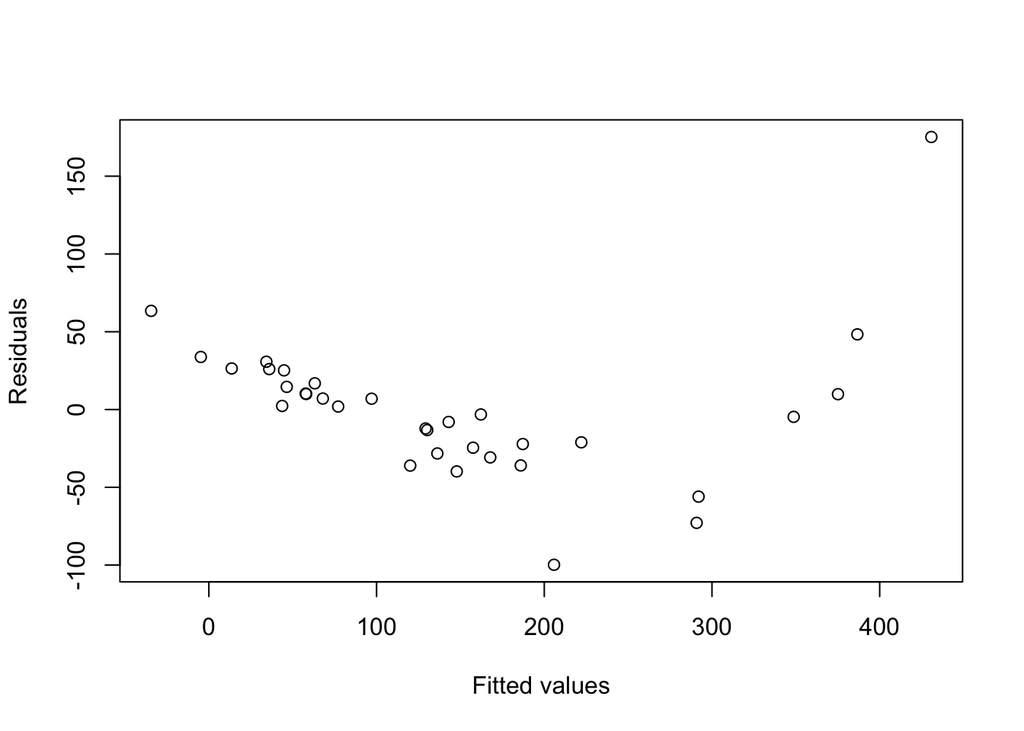

```r
plot(bestmodel1$fitted.values,bestmodel1$residuals,xlab="Fitted values",ylab="Residuals")
```

Test for the logarithm of the number of the breeding pairs.

```r
modelb<-lm(log(Breeding.pairs)~.,data=location) # Fit a linear model with Breeding pairs  as the response variable and everything else as a covariate
summary(modelb)
```

```
##
## Call:
## lm(formula = log(Breeding.pairs) ~ ., data = location)
##
## Residuals:
##       Min        1Q    Median        3Q       Max
## -0.205436 -0.047212  0.006141  0.034523  0.168295
##
## Coefficients:
##                       Estimate Std. Error t value Pr(>|t|)
## (Intercept)           1.055465   0.222334   4.747 6.55e-05 ***
## Coast.directionNorth -1.267524   0.048301 -26.242  < 2e-16 ***
## Coast.directionSouth -0.745748   0.047424 -15.725 8.49e-15 ***
## Coast.directionWest  -0.897742   0.044698 -20.085  < 2e-16 ***
## sandeel               0.298917   0.020034  14.920 2.92e-14 ***
## Summer.temp          -0.003829   0.006243  -0.613    0.545
## cliff.height          1.008390   0.037576  26.836  < 2e-16 ***
## ---
## Signif. codes:  0 '***' 0.001 '**' 0.01 '*' 0.05 '.' 0.1 ' ' 1
##
## Residual standard error: 0.08677 on 26 degrees of freedom
## Multiple R-squared:  0.9885, Adjusted R-squared:  0.9858
## F-statistic: 372.2 on 6 and 26 DF,  p-value: < 2.2e-16
```

```r
AIC(modelb)
```

```
## [1] -59.55727
```

Using the AIC function

```r
step(modelb,step=1) #
```

```
## Start:  AIC=-155.21
## log(Breeding.pairs) ~ Coast.direction + sandeel + Summer.temp +
##     cliff.height
##
##                   Df Sum of Sq    RSS      AIC
## - Summer.temp      1    0.0028 0.1986 -156.733
## <none>                         0.1957 -155.207
## - sandeel          1    1.6759 1.8717  -82.699
## - Coast.direction  3    5.5415 5.7372  -49.735
## - cliff.height     1    5.4217 5.6174  -46.431
##
## Step:  AIC=-156.73
## log(Breeding.pairs) ~ Coast.direction + sandeel + cliff.height
```

```
##
## Call:
## lm(formula = log(Breeding.pairs) ~ Coast.direction + sandeel +
##     cliff.height, data = location)
##
## Coefficients:
##          (Intercept)  Coast.directionNorth  Coast.directionSouth
##               0.9588               -1.2558               -0.7488
##  Coast.directionWest               sandeel          cliff.height
##              -0.8964                0.2977                1.0149
```

At the start the AIC is =-155.21

```r
modelb<-lm(log(Breeding.pairs)~.,data=location)
 # Fit a linear model with Breeding pairs  as the response variable and everything else as a covariate
step(modelb,step=2) # Try removing each covariate in turn.  Stop after two covariates have been removed ("step=2")
```

```
## Start:  AIC=-155.21
## log(Breeding.pairs) ~ Coast.direction + sandeel + Summer.temp +
##     cliff.height
##
##                   Df Sum of Sq    RSS      AIC
## - Summer.temp      1    0.0028 0.1986 -156.733
## <none>                         0.1957 -155.207
## - sandeel          1    1.6759 1.8717  -82.699
## - Coast.direction  3    5.5415 5.7372  -49.735
## - cliff.height     1    5.4217 5.6174  -46.431
##
## Step:  AIC=-156.73
## log(Breeding.pairs) ~ Coast.direction + sandeel + cliff.height
##
##                   Df Sum of Sq    RSS      AIC
## <none>                         0.1986 -156.733
## - sandeel          1    1.6791 1.8776  -84.594
## - Coast.direction  3    6.2201 6.4187  -48.031
## - cliff.height     1    5.9687 6.1672  -45.349
```

```
##
## Call:
## lm(formula = log(Breeding.pairs) ~ Coast.direction + sandeel +
##     cliff.height, data = location)
##
## Coefficients:
##          (Intercept)  Coast.directionNorth  Coast.directionSouth
##               0.9588               -1.2558               -0.7488
##  Coast.directionWest               sandeel          cliff.height
##              -0.8964                0.2977                1.0149
```

After removing Summer temp. in the first step the AIC reduces from -155.21 is -156.733. Removing Sandeel cause the AIC to increase to -84.594. We end the process.

```r
modelb<-lm(log(Breeding.pairs)~.,data=location)# Fit a linear model with Breeding pairs  as the response variable and everything else as a covariate
bestmodel2<-step(modelb) # Try removing each covariate in turn.  Stop when no further reduction in AIC can be found
```

```
## Start:  AIC=-155.21
## log(Breeding.pairs) ~ Coast.direction + sandeel + Summer.temp +
##     cliff.height
##
##                   Df Sum of Sq    RSS      AIC
## - Summer.temp      1    0.0028 0.1986 -156.733
## <none>                         0.1957 -155.207
## - sandeel          1    1.6759 1.8717  -82.699
## - Coast.direction  3    5.5415 5.7372  -49.735
## - cliff.height     1    5.4217 5.6174  -46.431
##
## Step:  AIC=-156.73
## log(Breeding.pairs) ~ Coast.direction + sandeel + cliff.height
##
##                   Df Sum of Sq    RSS      AIC
## <none>                         0.1986 -156.733
## - sandeel          1    1.6791 1.8776  -84.594
## - Coast.direction  3    6.2201 6.4187  -48.031
## - cliff.height     1    5.9687 6.1672  -45.349
```

```r
summary(bestmodel2) # Display a summary of the model with the lowest AIC
```

```
##
## Call:
## lm(formula = log(Breeding.pairs) ~ Coast.direction + sandeel +
##     cliff.height, data = location)
##
## Residuals:
##       Min        1Q    Median        3Q       Max
## -0.194905 -0.050959  0.004689  0.043078  0.169063
##
## Coefficients:
##                      Estimate Std. Error t value Pr(>|t|)
## (Intercept)           0.95885    0.15509   6.183 1.31e-06 ***
## Coast.directionNorth -1.25582    0.04386 -28.635  < 2e-16 ***
## Coast.directionSouth -0.74883    0.04661 -16.067 2.41e-15 ***
## Coast.directionWest  -0.89638    0.04412 -20.315  < 2e-16 ***
## sandeel               0.29768    0.01970  15.110 1.08e-14 ***
## cliff.height          1.01490    0.03563  28.488  < 2e-16 ***
## ---
## Signif. codes:  0 '***' 0.001 '**' 0.01 '*' 0.05 '.' 0.1 ' ' 1
##
## Residual standard error: 0.08576 on 27 degrees of freedom
## Multiple R-squared:  0.9883, Adjusted R-squared:  0.9862
## F-statistic: 457.1 on 5 and 27 DF,  p-value: < 2.2e-16
```

# Question 4d

For the model selected by the step function, we plot a histogram of the residuals and a scatter plot of residuals vs. fitted values

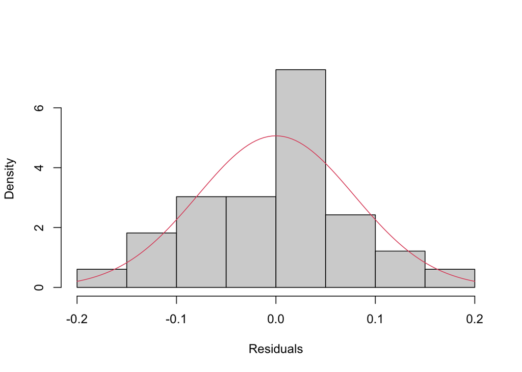

```r
hist(bestmodel2$residuals,xlab="Residuals",main="",freq=FALSE)
curve(dnorm(x,0,sd(bestmodel2$residuals)),-0.200,0.200,col=2,add=TRUE)
```

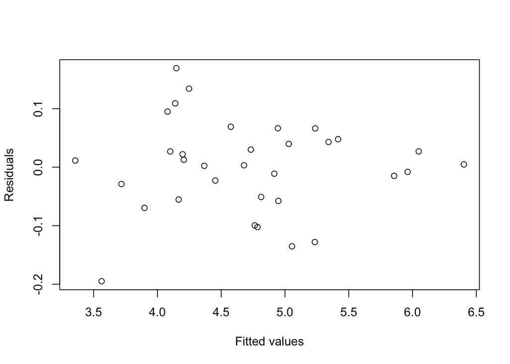

```r
plot(bestmodel2$fitted.values,bestmodel2$residuals,xlab="Fitted values",ylab="Residuals")
```

The residuals certainly appear to follow a normal distribution and there is no pattern in the residuals. Therefore the model assumptions appear to be adequately satisfied.

# Question 4e

```r
#prediction of the number of breeding pairs.

modelb<-lm(log(Breeding.pairs)~.,data=location)
pred_number=predict(modelb,newdata=data.frame(Coast.direction = "West", sandeel = 2.23, Summer.temp =19.9, cliff.height =3.5),interval='confidence', level = 0.98)
pred_number
```

```
##        fit      lwr      upr
## 1 4.277468 4.194717 4.360219
```

this provides the logarithm of the number of breeding pairs.

```r
no_of_breedingPairsfit <- exp(4.277468)
no_of_breedingPairsfit
```

```
## [1] 72.05776
```

```r
no_of_breedingPairslwr<-exp(4.194717)
no_of_breedingPairslwr
```

```
## [1] 66.33496
```

```r
no_of_breedingPairsUpr <- exp(4.360219)
no_of_breedingPairsUpr
```

```
## [1] 78.27427
```